# Highest mountains exploratory analysis

Borna Bejuk

January 26, 2018

## Data summary

```
## # A tibble: 6 x 11
##    Rank                                 Mountain Height..m. Height..ft.
##   <int>                                    <chr>      <int>       <int>
## 1     1 Mount Everest / Sagarmatha / Chomolungma       8848       29029
## 2     2               K2 / Qogir / Godwin Austen       8611       28251
## 3     3                            Kangchenjunga       8586       28169
## 4     4                                   Lhotse       8516       27940
## 5     5                                   Makalu       8485       27838
## 6     6                                  Cho Oyu       8188       26864
## # ... with 7 more variables: Prominence..m. <int>, Range <chr>,
## #   Coordinates <chr>, Parent.mountain <chr>, First.ascent <chr>,
## #   Ascents.bef..2004 <chr>, Failed.attempts.bef..2004 <int>
```

```
## Observations: 118
## Variables: 11
## $ Rank                      <int> 1, 2, 3, 4, 5, 6, 7, 8, 9, 10, 11, 1...
## $ Mountain                  <chr> "Mount Everest / Sagarmatha / Chomol...
## $ Height..m.                <int> 8848, 8611, 8586, 8516, 8485, 8188, ...
## $ Height..ft.               <int> 29029, 28251, 28169, 27940, 27838, 2...
## $ Prominence..m.            <int> 8848, 4017, 3922, 610, 2386, 2340, 3...
## $ Range                     <chr> "Mahalangur Himalaya", "Baltoro Kara...
## $ Coordinates               <chr> "27Â°59â²17â³N 86Â°55â²31â³Eï»¿ ...
## $ Parent.mountain           <chr> NA, "Mount Everest", "Mount Everest"...
## $ First.ascent              <chr> "1953", "1954", "1955", "1956", "195...
## $ Ascents.bef..2004         <chr> "145 ", "45", "38", "26", "45", "79"...
## $ Failed.attempts.bef..2004 <int> 121, 44, 24, 26, 52, 28, 39, 45, 67,...
```

```
##       Rank          Mountain           Height..m.    Height..ft.
##  Min.   :  1.00   Length:118         Min.   :7200   Min.   :23622
##  1st Qu.: 30.25   Class :character   1st Qu.:7316   1st Qu.:24004
##  Median : 59.50   Mode  :character   Median :7472   Median :24517
##  Mean   : 59.50                      Mean   :7578   Mean   :24862
##  3rd Qu.: 88.75                      3rd Qu.:7776   3rd Qu.:25510
##  Max.   :118.00                      Max.   :8848   Max.   :29029
##
##  Prominence..m.      Range           Coordinates        Parent.mountain
##  Min.   : 217.0   Length:118         Length:118         Length:118
##  1st Qu.: 712.8   Class :character   Class :character   Class :character
##  Median :1332.5   Mode  :character   Mode  :character   Mode  :character
##  Mean   :1671.6
##  3rd Qu.:2297.2
##  Max.   :8848.0
##
##  First.ascent       Ascents.bef..2004  Failed.attempts.bef..2004
##  Length:118         Length:118         Min.   :  0.0
##  Class :character   Class :character   1st Qu.:  1.0
##  Mode  :character   Mode  :character   Median :  3.0
##                                        Mean   :  8.4
##                                        3rd Qu.: 11.0
##                                        Max.   :121.0
##                                        NA's   :3
```

## 1. Let us first see the distribution of mountain heights in 10 bins

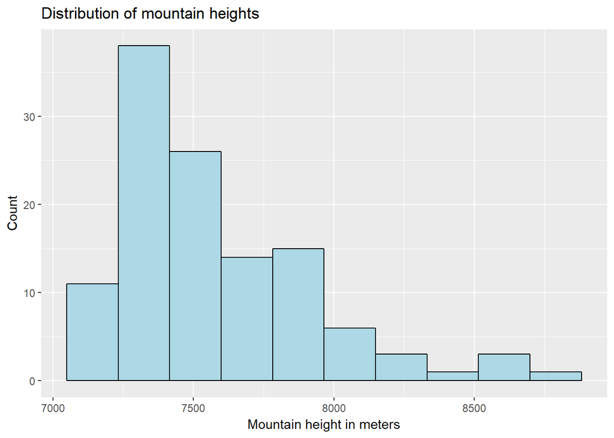

- The distribution is right skewed (median is to the left of the mean), meaning we have a small number of mountains that fall to the right of the mean and a large number that fall to the left of the mean.

## 2. Grouping the mountain heights into 5 groups based on their height

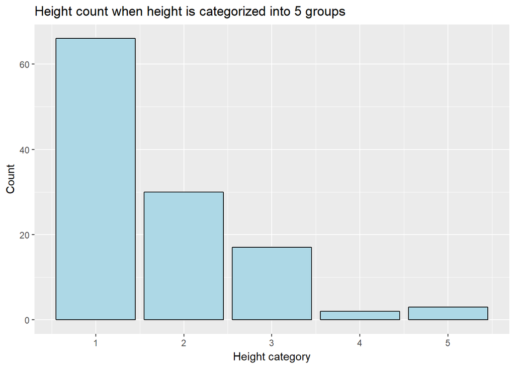

- We decided to divide the mountains into 5 categories based on their height to aid us in further analysis of the dataset
- Based on this initial grouping we see the most mountains fall into the first category

## 3. Let us see who are the parent mountains of our mountains when looking at our 5 groups

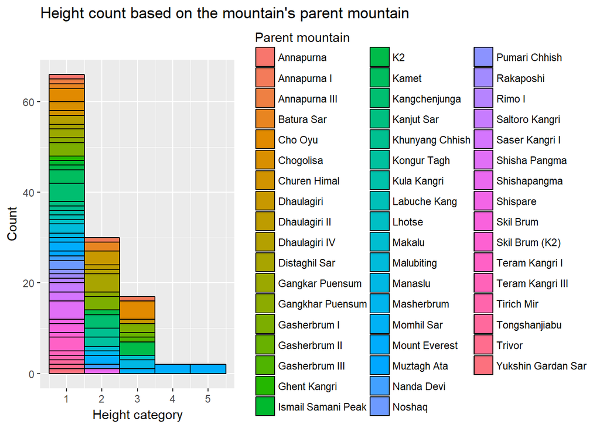

- We wanted the see if we could spot any link between the mountain’s height and its parent mountain
- We can see that the highest mountains mostly have Mount Everest as its parent mountain

## 4. Is there any link between the mountain height and the number of failed attempts ?

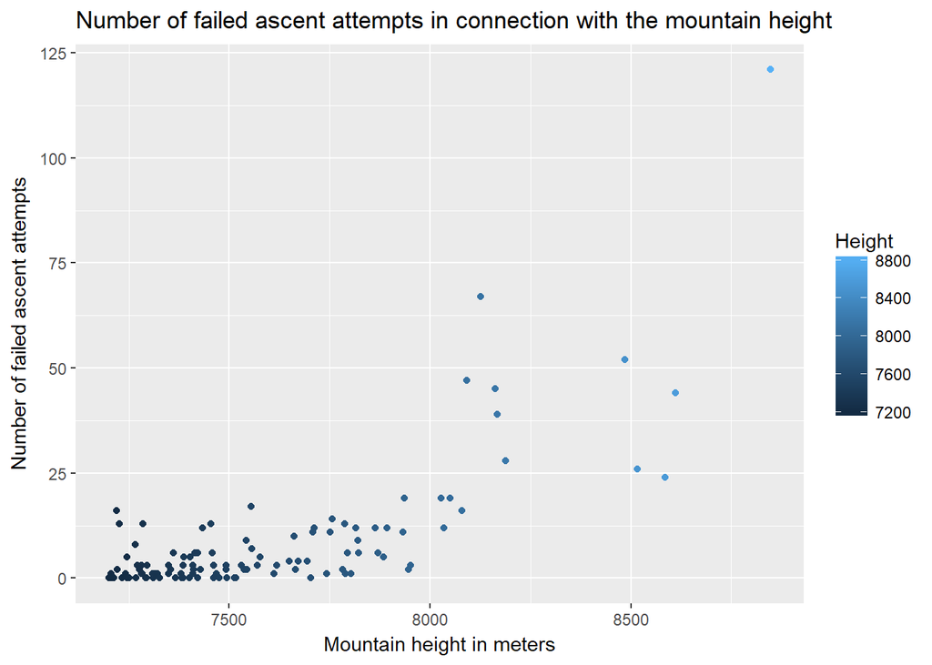

- Due to small number of data points it is hard to draw any conclusions but a sort of exponential growth is noticable

We can try to visualize the pattern using stat_smooth

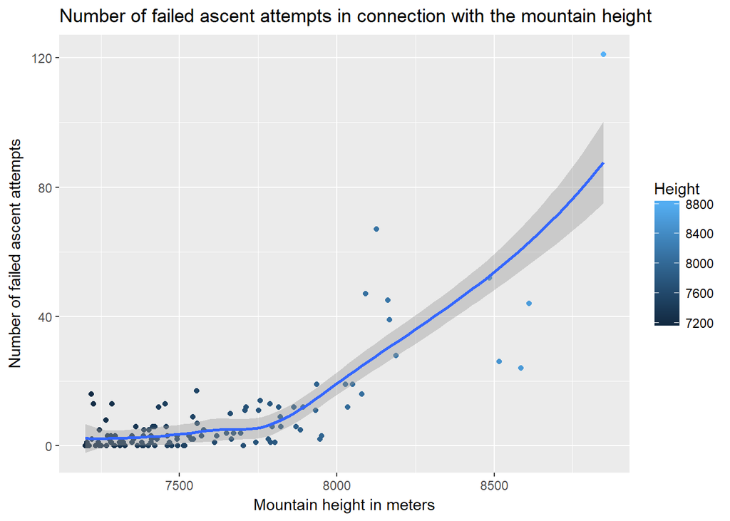

Or we could furhter try to improve our visualization by using different colors for each height category.

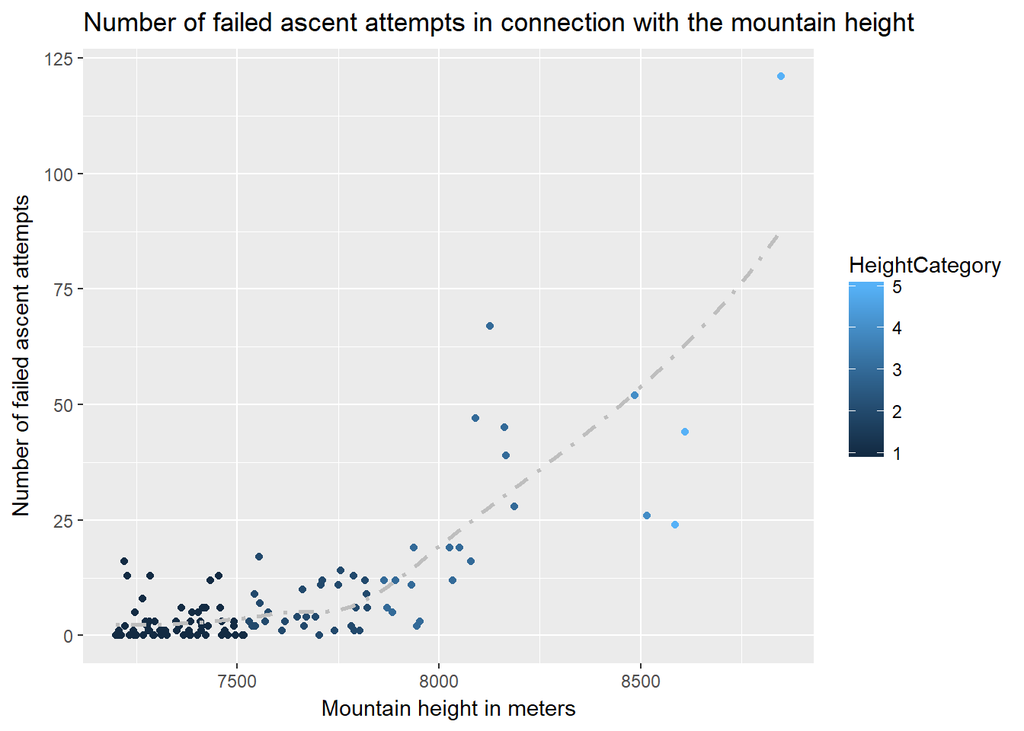

## 5. Let us again see the number of failed attempts for each height category using histogram

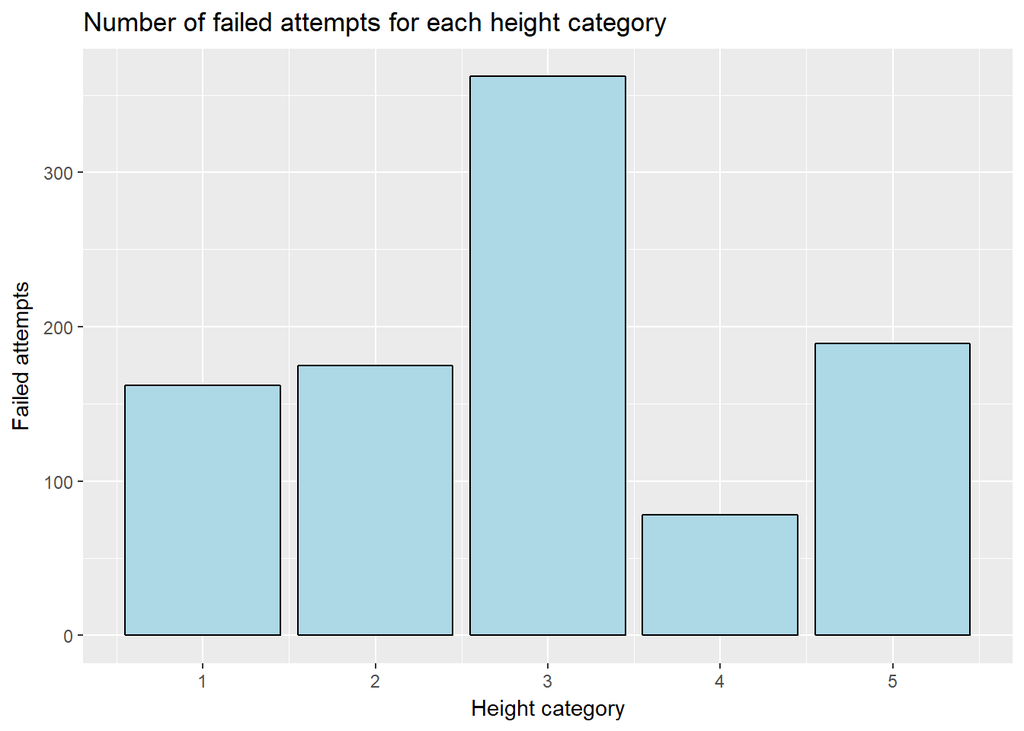

- Using histogram we can see that the third category of mountains was the most ‘trialed and errored’

## 6. Let’s investigate in which years were the mountain hikers most active

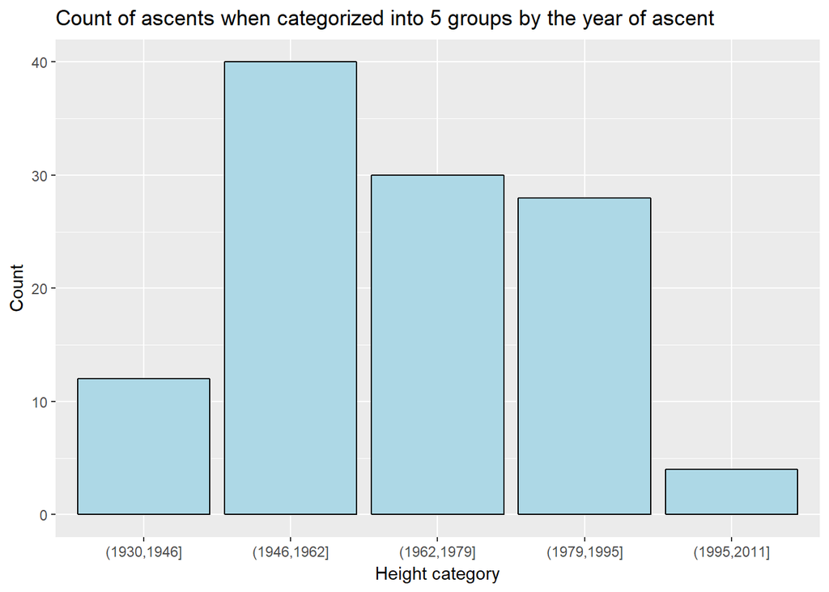

- We see that according to this dataset most ascents fall in the category that is between years 1946 and 1962.